# PCA y SMCCA-GS aplicado sobre una cohorte ómica de pacientes del proyecto ROSMAP

# 5 Distancia entre pares de puntos en el espacio de proyección

## 5.1 Discusión sobre las distancias

En secciones anteriores hemos mostrado una gráfica para cada conjunto de datos y para cada una de las dos técnicas utilizadas (PCA y SMCCA-GS), en la que se pueden visualizar los puntos coloreados según el valor de la variable de clase `cogdx`. Dado que estamos tratando de estudiar qué técnica devuelve mejores resultados, vamos a calcular la distancia entre los puntos según el valor de `cogdx`; y para realizar el cálculo de estas distancias, hemos utilizado dos métodos: `calinhara` y `dudahart2`.

La métrica `calinhara` (índice de Calinski-Harabasz) evalúa la calidad de los grupos obtenidos basándose en la varianza entre grupos y en la varianza dentro de los grupos. Por otro lado, `dudahart2` (índice de Dunn-Hartigan) devuelve en su parámetro `dh` la proporción entre la SSW (la variabilidad dentro de cada grupo -suma de las diferencias al cuadrado entre cada observación y su media grupal-) y la SST (variación total del conjunto de datos -suma de las diferencias al cuadrado entre cada observación y la media general-).

Por lo tanto, cuanto mayor sea el valor devuelto por `calinhara`, mayor será la distancia y, por ende, mejor el clustering dado; mientras que con el parámetro `dh` de `dudahart2` sucede lo opuesto, cuanto menor sea el valor obtenido, menor será la varianza dentro de los clusters en comparación con la varianza dentro de un único cluster, por lo que, cuanto menor sea el valor, mejor será el clustering tratado.

```r
# PCA
dist_PCA_cleandat <- calculos_distancias(data_pcas_plot_cleandat, data_pcas_plot_cleandat$cogdx)
dist_PCA_metabolon <- calculos_distancias(data_pcas_plot_metabolon, data_pcas_plot_metabolon$cogdx)
dist_PCA_rinpmiagesex <- calculos_distancias(data_pcas_plot_rinpmiagesex, data_pcas_plot_rinpmiagesex$cogdx)

# SMCCA-GS
dist_SMCCA_GS_cleandat <- calculos_distancias(data_SMCCA_GS_plot_cleandat, data_SMCCA_GS_plot_cleandat$cogdx)
dist_SMCCA_GS_metabolon <- calculos_distancias(data_SMCCA_GS_plot_metabolon, data_SMCCA_GS_plot_metabolon$cogdx)
dist_SMCCA_GS_rinpmiagesex <- calculos_distancias(data_SMCCA_GS_plot_rinpmiagesex, data_SMCCA_GS_plot_rinpmiagesex$cogdx)
```

Los resultados obtenidos con `calinhara` son los siguientes:

| Dataset | PCA | SMCCA-GS |
| --- | --- | --- |
| cleandat | 0.2640063 | 3.411297 |
| metabolon | 2.2103743 | 23.2924627 |
| rinpmiagesex | 1.5908195 | 1.7474942 |

En la siguiente tabla se muestran los resultados obtenidos con el método `dudahart2`. En este caso nos hemos fijado en el parámetro `$dh`.

| Dataset | PCA | SMCCA-GS |
| --- | --- | --- |
| cleandat | 0.9960158 | 0.9508539 |
| metabolon | 0.9675947 | 0.7391441 |
| rinpmiagesex | 0.976464 | 0.9742058 |

## 5.2 Aplicamos bootstrapping

Para ahondar en el estudio de las distancias de los puntos y ver qué técnica realiza un mejor agrupamiento de los datos, vamos a aplicar la técnica “bootstrapping”. Para ello, vamos a tomar, de cada conjunto de datos, con repetición de todos los valores. Esto lo vamos a realizar diez veces:

```r
resample <- createResample(data_pcas_plot_cleandat[[pca_result_total_ROSMAP.Var.Salida.Usada]],
                                   list = TRUE,
                                   times = 10)
```

Creamos los conjuntos de datos con los remuestreos que acabamos de hacer:

```r
# Creamos los conjuntos de datos de PCA
data_pcas_plot_cleandat.resample_1 <- data_pcas_plot_cleandat[resample[[1]], ]
data_pcas_plot_cleandat.resample_2 <- data_pcas_plot_cleandat[resample[[2]], ]
data_pcas_plot_cleandat.resample_3 <- data_pcas_plot_cleandat[resample[[3]], ]
data_pcas_plot_cleandat.resample_4 <- data_pcas_plot_cleandat[resample[[4]], ]
data_pcas_plot_cleandat.resample_5 <- data_pcas_plot_cleandat[resample[[5]], ]
data_pcas_plot_cleandat.resample_6 <- data_pcas_plot_cleandat[resample[[6]], ]
data_pcas_plot_cleandat.resample_7 <- data_pcas_plot_cleandat[resample[[7]], ]
data_pcas_plot_cleandat.resample_8 <- data_pcas_plot_cleandat[resample[[8]], ]
data_pcas_plot_cleandat.resample_9 <- data_pcas_plot_cleandat[resample[[9]], ]
data_pcas_plot_cleandat.resample_10 <- data_pcas_plot_cleandat[resample[[10]], ]

data_pcas_plot_metabolon.resample_1 <- data_pcas_plot_metabolon[resample[[1]], ]
data_pcas_plot_metabolon.resample_2 <- data_pcas_plot_metabolon[resample[[2]], ]
data_pcas_plot_metabolon.resample_3 <- data_pcas_plot_metabolon[resample[[3]], ]
data_pcas_plot_metabolon.resample_4 <- data_pcas_plot_metabolon[resample[[4]], ]
data_pcas_plot_metabolon.resample_5 <- data_pcas_plot_metabolon[resample[[5]], ]
data_pcas_plot_metabolon.resample_6 <- data_pcas_plot_metabolon[resample[[6]], ]
data_pcas_plot_metabolon.resample_7 <- data_pcas_plot_metabolon[resample[[7]], ]
data_pcas_plot_metabolon.resample_8 <- data_pcas_plot_metabolon[resample[[8]], ]
data_pcas_plot_metabolon.resample_9 <- data_pcas_plot_metabolon[resample[[9]], ]
data_pcas_plot_metabolon.resample_10 <- data_pcas_plot_metabolon[resample[[10]], ]

data_pcas_plot_rinpmiagesex.resample_1 <- data_pcas_plot_rinpmiagesex[resample[[1]], ]
data_pcas_plot_rinpmiagesex.resample_2 <- data_pcas_plot_rinpmiagesex[resample[[2]], ]
data_pcas_plot_rinpmiagesex.resample_3 <- data_pcas_plot_rinpmiagesex[resample[[3]], ]
data_pcas_plot_rinpmiagesex.resample_4 <- data_pcas_plot_rinpmiagesex[resample[[4]], ]
data_pcas_plot_rinpmiagesex.resample_5 <- data_pcas_plot_rinpmiagesex[resample[[5]], ]
data_pcas_plot_rinpmiagesex.resample_6 <- data_pcas_plot_rinpmiagesex[resample[[6]], ]
data_pcas_plot_rinpmiagesex.resample_7 <- data_pcas_plot_rinpmiagesex[resample[[7]], ]
data_pcas_plot_rinpmiagesex.resample_8 <- data_pcas_plot_rinpmiagesex[resample[[8]], ]
data_pcas_plot_rinpmiagesex.resample_9 <- data_pcas_plot_rinpmiagesex[resample[[9]], ]
data_pcas_plot_rinpmiagesex.resample_10 <- data_pcas_plot_rinpmiagesex[resample[[10]], ]

# Creamos los conjuntos de datos de SMCCA-GS
data_SMCCA_GS_plot_cleandat.resample_1 <- data_SMCCA_GS_plot_cleandat[resample[[1]], ]
data_SMCCA_GS_plot_cleandat.resample_2 <- data_SMCCA_GS_plot_cleandat[resample[[2]], ]
data_SMCCA_GS_plot_cleandat.resample_3 <- data_SMCCA_GS_plot_cleandat[resample[[3]], ]
data_SMCCA_GS_plot_cleandat.resample_4 <- data_SMCCA_GS_plot_cleandat[resample[[4]], ]
data_SMCCA_GS_plot_cleandat.resample_5 <- data_SMCCA_GS_plot_cleandat[resample[[5]], ]
data_SMCCA_GS_plot_cleandat.resample_6 <- data_SMCCA_GS_plot_cleandat[resample[[6]], ]
data_SMCCA_GS_plot_cleandat.resample_7 <- data_SMCCA_GS_plot_cleandat[resample[[7]], ]
data_SMCCA_GS_plot_cleandat.resample_8 <- data_SMCCA_GS_plot_cleandat[resample[[8]], ]
data_SMCCA_GS_plot_cleandat.resample_9 <- data_SMCCA_GS_plot_cleandat[resample[[9]], ]
data_SMCCA_GS_plot_cleandat.resample_10 <- data_SMCCA_GS_plot_cleandat[resample[[10]], ]

data_SMCCA_GS_plot_metabolon.resample_1 <- data_SMCCA_GS_plot_metabolon[resample[[1]], ]
data_SMCCA_GS_plot_metabolon.resample_2 <- data_SMCCA_GS_plot_metabolon[resample[[2]], ]
data_SMCCA_GS_plot_metabolon.resample_3 <- data_SMCCA_GS_plot_metabolon[resample[[3]], ]
data_SMCCA_GS_plot_metabolon.resample_4 <- data_SMCCA_GS_plot_metabolon[resample[[4]], ]
data_SMCCA_GS_plot_metabolon.resample_5 <- data_SMCCA_GS_plot_metabolon[resample[[5]], ]
data_SMCCA_GS_plot_metabolon.resample_6 <- data_SMCCA_GS_plot_metabolon[resample[[6]], ]
data_SMCCA_GS_plot_metabolon.resample_7 <- data_SMCCA_GS_plot_metabolon[resample[[7]], ]
data_SMCCA_GS_plot_metabolon.resample_8 <- data_SMCCA_GS_plot_metabolon[resample[[8]], ]
data_SMCCA_GS_plot_metabolon.resample_9 <- data_SMCCA_GS_plot_metabolon[resample[[9]], ]
data_SMCCA_GS_plot_metabolon.resample_10 <- data_SMCCA_GS_plot_metabolon[resample[[10]], ]

data_SMCCA_GS_plot_rinpmiagesex.resample_1 <- data_SMCCA_GS_plot_rinpmiagesex[resample[[1]], ]
data_SMCCA_GS_plot_rinpmiagesex.resample_2 <- data_SMCCA_GS_plot_rinpmiagesex[resample[[2]], ]
data_SMCCA_GS_plot_rinpmiagesex.resample_3 <- data_SMCCA_GS_plot_rinpmiagesex[resample[[3]], ]
data_SMCCA_GS_plot_rinpmiagesex.resample_4 <- data_SMCCA_GS_plot_rinpmiagesex[resample[[4]], ]
data_SMCCA_GS_plot_rinpmiagesex.resample_5 <- data_SMCCA_GS_plot_rinpmiagesex[resample[[5]], ]
data_SMCCA_GS_plot_rinpmiagesex.resample_6 <- data_SMCCA_GS_plot_rinpmiagesex[resample[[6]], ]
data_SMCCA_GS_plot_rinpmiagesex.resample_7 <- data_SMCCA_GS_plot_rinpmiagesex[resample[[7]], ]
data_SMCCA_GS_plot_rinpmiagesex.resample_8 <- data_SMCCA_GS_plot_rinpmiagesex[resample[[8]], ]
data_SMCCA_GS_plot_rinpmiagesex.resample_9 <- data_SMCCA_GS_plot_rinpmiagesex[resample[[9]], ]
data_SMCCA_GS_plot_rinpmiagesex.resample_10 <- data_SMCCA_GS_plot_rinpmiagesex[resample[[10]], ]
```

Calculamos las distancias de los remuestreos:

```r
# Calculamos las distancias de PCA
dist_PCA_cleandat.resample_1 <- calculos_distancias(data_pcas_plot_cleandat.resample_1, data_pcas_plot_cleandat.resample_1$cogdx)
dist_PCA_cleandat.resample_2 <- calculos_distancias(data_pcas_plot_cleandat.resample_2, data_pcas_plot_cleandat.resample_2$cogdx)
dist_PCA_cleandat.resample_3 <- calculos_distancias(data_pcas_plot_cleandat.resample_3, data_pcas_plot_cleandat.resample_3$cogdx)
dist_PCA_cleandat.resample_4 <- calculos_distancias(data_pcas_plot_cleandat.resample_4, data_pcas_plot_cleandat.resample_4$cogdx)
dist_PCA_cleandat.resample_5 <- calculos_distancias(data_pcas_plot_cleandat.resample_5, data_pcas_plot_cleandat.resample_5$cogdx)
dist_PCA_cleandat.resample_6 <- calculos_distancias(data_pcas_plot_cleandat.resample_6, data_pcas_plot_cleandat.resample_6$cogdx)
dist_PCA_cleandat.resample_7 <- calculos_distancias(data_pcas_plot_cleandat.resample_7, data_pcas_plot_cleandat.resample_7$cogdx)
dist_PCA_cleandat.resample_8 <- calculos_distancias(data_pcas_plot_cleandat.resample_8, data_pcas_plot_cleandat.resample_8$cogdx)
dist_PCA_cleandat.resample_9 <- calculos_distancias(data_pcas_plot_cleandat.resample_9, data_pcas_plot_cleandat.resample_9$cogdx)
dist_PCA_cleandat.resample_10 <- calculos_distancias(data_pcas_plot_cleandat.resample_10, data_pcas_plot_cleandat.resample_10$cogdx)

dist_PCA_metabolon.resample_1 <- calculos_distancias(data_pcas_plot_metabolon.resample_1, data_pcas_plot_metabolon.resample_1$cogdx)
dist_PCA_metabolon.resample_2 <- calculos_distancias(data_pcas_plot_metabolon.resample_2, data_pcas_plot_metabolon.resample_2$cogdx)
dist_PCA_metabolon.resample_3 <- calculos_distancias(data_pcas_plot_metabolon.resample_3, data_pcas_plot_metabolon.resample_3$cogdx)
dist_PCA_metabolon.resample_4 <- calculos_distancias(data_pcas_plot_metabolon.resample_4, data_pcas_plot_metabolon.resample_4$cogdx)
dist_PCA_metabolon.resample_5 <- calculos_distancias(data_pcas_plot_metabolon.resample_5, data_pcas_plot_metabolon.resample_5$cogdx)
dist_PCA_metabolon.resample_6 <- calculos_distancias(data_pcas_plot_metabolon.resample_6, data_pcas_plot_metabolon.resample_6$cogdx)
dist_PCA_metabolon.resample_7 <- calculos_distancias(data_pcas_plot_metabolon.resample_7, data_pcas_plot_metabolon.resample_7$cogdx)
dist_PCA_metabolon.resample_8 <- calculos_distancias(data_pcas_plot_metabolon.resample_8, data_pcas_plot_metabolon.resample_8$cogdx)
dist_PCA_metabolon.resample_9 <- calculos_distancias(data_pcas_plot_metabolon.resample_9, data_pcas_plot_metabolon.resample_9$cogdx)
dist_PCA_metabolon.resample_10 <- calculos_distancias(data_pcas_plot_metabolon.resample_10, data_pcas_plot_metabolon.resample_10$cogdx)

dist_PCA_rinpmiagesex.resample_1 <- calculos_distancias(data_pcas_plot_rinpmiagesex.resample_1, data_pcas_plot_rinpmiagesex.resample_1$cogdx)
dist_PCA_rinpmiagesex.resample_2 <- calculos_distancias(data_pcas_plot_rinpmiagesex.resample_2, data_pcas_plot_rinpmiagesex.resample_2$cogdx)
dist_PCA_rinpmiagesex.resample_3 <- calculos_distancias(data_pcas_plot_rinpmiagesex.resample_3, data_pcas_plot_rinpmiagesex.resample_3$cogdx)
dist_PCA_rinpmiagesex.resample_4 <- calculos_distancias(data_pcas_plot_rinpmiagesex.resample_4, data_pcas_plot_rinpmiagesex.resample_4$cogdx)
dist_PCA_rinpmiagesex.resample_5 <- calculos_distancias(data_pcas_plot_rinpmiagesex.resample_5, data_pcas_plot_rinpmiagesex.resample_5$cogdx)
dist_PCA_rinpmiagesex.resample_6 <- calculos_distancias(data_pcas_plot_rinpmiagesex.resample_6, data_pcas_plot_rinpmiagesex.resample_6$cogdx)
dist_PCA_rinpmiagesex.resample_7 <- calculos_distancias(data_pcas_plot_rinpmiagesex.resample_7, data_pcas_plot_rinpmiagesex.resample_7$cogdx)
dist_PCA_rinpmiagesex.resample_8 <- calculos_distancias(data_pcas_plot_rinpmiagesex.resample_8, data_pcas_plot_rinpmiagesex.resample_8$cogdx)
dist_PCA_rinpmiagesex.resample_9 <- calculos_distancias(data_pcas_plot_rinpmiagesex.resample_9, data_pcas_plot_rinpmiagesex.resample_9$cogdx)
dist_PCA_rinpmiagesex.resample_10 <- calculos_distancias(data_pcas_plot_rinpmiagesex.resample_10, data_pcas_plot_rinpmiagesex.resample_10$cogdx)

# Calculamos las distancias de SMCCA-GS
dist_SMCCA_GS_cleandat.resample_1 <- calculos_distancias(data_SMCCA_GS_plot_cleandat.resample_1, data_SMCCA_GS_plot_cleandat.resample_1$cogdx)
dist_SMCCA_GS_cleandat.resample_2 <- calculos_distancias(data_SMCCA_GS_plot_cleandat.resample_2, data_SMCCA_GS_plot_cleandat.resample_2$cogdx)
dist_SMCCA_GS_cleandat.resample_3 <- calculos_distancias(data_SMCCA_GS_plot_cleandat.resample_3, data_SMCCA_GS_plot_cleandat.resample_3$cogdx)
dist_SMCCA_GS_cleandat.resample_4 <- calculos_distancias(data_SMCCA_GS_plot_cleandat.resample_4, data_SMCCA_GS_plot_cleandat.resample_4$cogdx)
dist_SMCCA_GS_cleandat.resample_5 <- calculos_distancias(data_SMCCA_GS_plot_cleandat.resample_5, data_SMCCA_GS_plot_cleandat.resample_5$cogdx)
dist_SMCCA_GS_cleandat.resample_6 <- calculos_distancias(data_SMCCA_GS_plot_cleandat.resample_6, data_SMCCA_GS_plot_cleandat.resample_6$cogdx)
dist_SMCCA_GS_cleandat.resample_7 <- calculos_distancias(data_SMCCA_GS_plot_cleandat.resample_7, data_SMCCA_GS_plot_cleandat.resample_7$cogdx)
dist_SMCCA_GS_cleandat.resample_8 <- calculos_distancias(data_SMCCA_GS_plot_cleandat.resample_8, data_SMCCA_GS_plot_cleandat.resample_8$cogdx)
dist_SMCCA_GS_cleandat.resample_9 <- calculos_distancias(data_SMCCA_GS_plot_cleandat.resample_9, data_SMCCA_GS_plot_cleandat.resample_9$cogdx)
dist_SMCCA_GS_cleandat.resample_10 <- calculos_distancias(data_SMCCA_GS_plot_cleandat.resample_10, data_SMCCA_GS_plot_cleandat.resample_10$cogdx)

dist_SMCCA_GS_metabolon.resample_1 <- calculos_distancias(data_SMCCA_GS_plot_metabolon.resample_1, data_SMCCA_GS_plot_metabolon.resample_1$cogdx)
dist_SMCCA_GS_metabolon.resample_2 <- calculos_distancias(data_SMCCA_GS_plot_metabolon.resample_2, data_SMCCA_GS_plot_metabolon.resample_2$cogdx)
dist_SMCCA_GS_metabolon.resample_3 <- calculos_distancias(data_SMCCA_GS_plot_metabolon.resample_3, data_SMCCA_GS_plot_metabolon.resample_3$cogdx)
dist_SMCCA_GS_metabolon.resample_4 <- calculos_distancias(data_SMCCA_GS_plot_metabolon.resample_4, data_SMCCA_GS_plot_metabolon.resample_4$cogdx)
dist_SMCCA_GS_metabolon.resample_5 <- calculos_distancias(data_SMCCA_GS_plot_metabolon.resample_5, data_SMCCA_GS_plot_metabolon.resample_5$cogdx)
dist_SMCCA_GS_metabolon.resample_6 <- calculos_distancias(data_SMCCA_GS_plot_metabolon.resample_6, data_SMCCA_GS_plot_metabolon.resample_6$cogdx)
dist_SMCCA_GS_metabolon.resample_7 <- calculos_distancias(data_SMCCA_GS_plot_metabolon.resample_7, data_SMCCA_GS_plot_metabolon.resample_7$cogdx)
dist_SMCCA_GS_metabolon.resample_8 <- calculos_distancias(data_SMCCA_GS_plot_metabolon.resample_8, data_SMCCA_GS_plot_metabolon.resample_8$cogdx)
dist_SMCCA_GS_metabolon.resample_9 <- calculos_distancias(data_SMCCA_GS_plot_metabolon.resample_9, data_SMCCA_GS_plot_metabolon.resample_9$cogdx)
dist_SMCCA_GS_metabolon.resample_10 <- calculos_distancias(data_SMCCA_GS_plot_metabolon.resample_10, data_SMCCA_GS_plot_metabolon.resample_10$cogdx)

dist_SMCCA_GS_rinpmiagesex.resample_1 <- calculos_distancias(data_SMCCA_GS_plot_rinpmiagesex.resample_1, data_SMCCA_GS_plot_rinpmiagesex.resample_1$cogdx)
dist_SMCCA_GS_rinpmiagesex.resample_2 <- calculos_distancias(data_SMCCA_GS_plot_rinpmiagesex.resample_2, data_SMCCA_GS_plot_rinpmiagesex.resample_2$cogdx)
dist_SMCCA_GS_rinpmiagesex.resample_3 <- calculos_distancias(data_SMCCA_GS_plot_rinpmiagesex.resample_3, data_SMCCA_GS_plot_rinpmiagesex.resample_3$cogdx)
dist_SMCCA_GS_rinpmiagesex.resample_4 <- calculos_distancias(data_SMCCA_GS_plot_rinpmiagesex.resample_4, data_SMCCA_GS_plot_rinpmiagesex.resample_4$cogdx)
dist_SMCCA_GS_rinpmiagesex.resample_5 <- calculos_distancias(data_SMCCA_GS_plot_rinpmiagesex.resample_5, data_SMCCA_GS_plot_rinpmiagesex.resample_5$cogdx)
dist_SMCCA_GS_rinpmiagesex.resample_6 <- calculos_distancias(data_SMCCA_GS_plot_rinpmiagesex.resample_6, data_SMCCA_GS_plot_rinpmiagesex.resample_6$cogdx)
dist_SMCCA_GS_rinpmiagesex.resample_7 <- calculos_distancias(data_SMCCA_GS_plot_rinpmiagesex.resample_7, data_SMCCA_GS_plot_rinpmiagesex.resample_7$cogdx)
dist_SMCCA_GS_rinpmiagesex.resample_8 <- calculos_distancias(data_SMCCA_GS_plot_rinpmiagesex.resample_8, data_SMCCA_GS_plot_rinpmiagesex.resample_8$cogdx)
dist_SMCCA_GS_rinpmiagesex.resample_9 <- calculos_distancias(data_SMCCA_GS_plot_rinpmiagesex.resample_9, data_SMCCA_GS_plot_rinpmiagesex.resample_9$cogdx)
dist_SMCCA_GS_rinpmiagesex.resample_10 <- calculos_distancias(data_SMCCA_GS_plot_rinpmiagesex.resample_10, data_SMCCA_GS_plot_rinpmiagesex.resample_10$cogdx)
```

Los intervalos de confianza los vamos a hallar utilizando una función auxiliar. Para ello, primero guardamos las distancias obtenidas en vectores:

```r
# Guardamos los valores obtenidos en distintos vectores según la técnica utilizada (PCA o SMCCA_GS), el conjunto de datos y el método usado para hallar la distancia (calinhara o dudahart2)

# PCA
v_dist_PCA_cleandat_calinhara = c(dist_PCA_cleandat.resample_1[[1]], dist_PCA_cleandat.resample_2[[1]], dist_PCA_cleandat.resample_3[[1]], dist_PCA_cleandat.resample_4[[1]], dist_PCA_cleandat.resample_5[[1]], dist_PCA_cleandat.resample_6[[1]], dist_PCA_cleandat.resample_7[[1]], dist_PCA_cleandat.resample_8[[1]], dist_PCA_cleandat.resample_9[[1]], dist_PCA_cleandat.resample_10[[1]])

v_dist_PCA_cleandat_dudahart2 = c(dist_PCA_cleandat.resample_1[[2]]$dh, dist_PCA_cleandat.resample_2[[2]]$dh, dist_PCA_cleandat.resample_3[[2]]$dh, dist_PCA_cleandat.resample_4[[2]]$dh, dist_PCA_cleandat.resample_5[[2]]$dh, dist_PCA_cleandat.resample_6[[2]]$dh, dist_PCA_cleandat.resample_7[[2]]$dh, dist_PCA_cleandat.resample_8[[2]]$dh, dist_PCA_cleandat.resample_9[[2]]$dh, dist_PCA_cleandat.resample_10[[2]]$dh)

v_dist_PCA_metabolon_calinhara = c(dist_PCA_metabolon.resample_1[[1]], dist_PCA_metabolon.resample_2[[1]], dist_PCA_metabolon.resample_3[[1]], dist_PCA_metabolon.resample_4[[1]], dist_PCA_metabolon.resample_5[[1]], dist_PCA_metabolon.resample_6[[1]], dist_PCA_metabolon.resample_7[[1]], dist_PCA_metabolon.resample_8[[1]], dist_PCA_metabolon.resample_9[[1]], dist_PCA_metabolon.resample_10[[1]])

v_dist_PCA_metabolon_dudahart2 = c(dist_PCA_metabolon.resample_1[[2]]$dh, dist_PCA_metabolon.resample_2[[2]]$dh, dist_PCA_metabolon.resample_3[[2]]$dh, dist_PCA_metabolon.resample_4[[2]]$dh, dist_PCA_metabolon.resample_5[[2]]$dh, dist_PCA_metabolon.resample_6[[2]]$dh, dist_PCA_metabolon.resample_7[[2]]$dh, dist_PCA_metabolon.resample_8[[2]]$dh, dist_PCA_metabolon.resample_9[[2]]$dh, dist_PCA_metabolon.resample_10[[2]]$dh)

v_dist_PCA_rinpmiagesex_calinhara = c(dist_PCA_rinpmiagesex.resample_1[[1]], dist_PCA_rinpmiagesex.resample_2[[1]], dist_PCA_rinpmiagesex.resample_3[[1]], dist_PCA_rinpmiagesex.resample_4[[1]], dist_PCA_rinpmiagesex.resample_5[[1]], dist_PCA_rinpmiagesex.resample_6[[1]], dist_PCA_rinpmiagesex.resample_7[[1]], dist_PCA_rinpmiagesex.resample_8[[1]], dist_PCA_rinpmiagesex.resample_9[[1]], dist_PCA_rinpmiagesex.resample_10[[1]])

v_dist_PCA_rinpmiagesex_dudahart2 = c(dist_PCA_rinpmiagesex.resample_1[[2]]$dh, dist_PCA_rinpmiagesex.resample_2[[2]]$dh, dist_PCA_rinpmiagesex.resample_3[[2]]$dh, dist_PCA_rinpmiagesex.resample_4[[2]]$dh, dist_PCA_rinpmiagesex.resample_5[[2]]$dh, dist_PCA_rinpmiagesex.resample_6[[2]]$dh, dist_PCA_rinpmiagesex.resample_7[[2]]$dh, dist_PCA_rinpmiagesex.resample_8[[2]]$dh, dist_PCA_rinpmiagesex.resample_9[[2]]$dh, dist_PCA_rinpmiagesex.resample_10[[2]]$dh)

# SMCCA-GS
v_dist_SMCCA_GS_cleandat_calinhara = c(dist_SMCCA_GS_cleandat.resample_1[[1]], dist_SMCCA_GS_cleandat.resample_2[[1]], dist_SMCCA_GS_cleandat.resample_3[[1]], dist_SMCCA_GS_cleandat.resample_4[[1]], dist_SMCCA_GS_cleandat.resample_5[[1]], dist_SMCCA_GS_cleandat.resample_6[[1]], dist_SMCCA_GS_cleandat.resample_7[[1]], dist_SMCCA_GS_cleandat.resample_8[[1]], dist_SMCCA_GS_cleandat.resample_9[[1]], dist_SMCCA_GS_cleandat.resample_10[[1]])

v_dist_SMCCA_GS_cleandat_dudahart2 = c(dist_SMCCA_GS_cleandat.resample_1[[2]]$dh, dist_SMCCA_GS_cleandat.resample_2[[2]]$dh, dist_SMCCA_GS_cleandat.resample_3[[2]]$dh, dist_SMCCA_GS_cleandat.resample_4[[2]]$dh, dist_SMCCA_GS_cleandat.resample_5[[2]]$dh, dist_SMCCA_GS_cleandat.resample_6[[2]]$dh, dist_SMCCA_GS_cleandat.resample_7[[2]]$dh, dist_SMCCA_GS_cleandat.resample_8[[2]]$dh, dist_SMCCA_GS_cleandat.resample_9[[2]]$dh, dist_SMCCA_GS_cleandat.resample_10[[2]]$dh)

v_dist_SMCCA_GS_metabolon_calinhara = c(dist_SMCCA_GS_metabolon.resample_1[[1]], dist_SMCCA_GS_metabolon.resample_2[[1]], dist_SMCCA_GS_metabolon.resample_3[[1]], dist_SMCCA_GS_metabolon.resample_4[[1]], dist_SMCCA_GS_metabolon.resample_5[[1]], dist_SMCCA_GS_metabolon.resample_6[[1]], dist_SMCCA_GS_metabolon.resample_7[[1]], dist_SMCCA_GS_metabolon.resample_8[[1]], dist_SMCCA_GS_metabolon.resample_9[[1]], dist_SMCCA_GS_metabolon.resample_10[[1]])

v_dist_SMCCA_GS_metabolon_dudahart2 = c(dist_SMCCA_GS_metabolon.resample_1[[2]]$dh, dist_SMCCA_GS_metabolon.resample_2[[2]]$dh, dist_SMCCA_GS_metabolon.resample_3[[2]]$dh, dist_SMCCA_GS_metabolon.resample_4[[2]]$dh, dist_SMCCA_GS_metabolon.resample_5[[2]]$dh, dist_SMCCA_GS_metabolon.resample_6[[2]]$dh, dist_SMCCA_GS_metabolon.resample_7[[2]]$dh, dist_SMCCA_GS_metabolon.resample_8[[2]]$dh, dist_SMCCA_GS_metabolon.resample_9[[2]]$dh, dist_SMCCA_GS_metabolon.resample_10[[2]]$dh)

v_dist_SMCCA_GS_rinpmiagesex_calinhara = c(dist_SMCCA_GS_rinpmiagesex.resample_1[[1]], dist_SMCCA_GS_rinpmiagesex.resample_2[[1]], dist_SMCCA_GS_rinpmiagesex.resample_3[[1]], dist_SMCCA_GS_rinpmiagesex.resample_4[[1]], dist_SMCCA_GS_rinpmiagesex.resample_5[[1]], dist_SMCCA_GS_rinpmiagesex.resample_6[[1]], dist_SMCCA_GS_rinpmiagesex.resample_7[[1]], dist_SMCCA_GS_rinpmiagesex.resample_8[[1]], dist_SMCCA_GS_rinpmiagesex.resample_9[[1]], dist_SMCCA_GS_rinpmiagesex.resample_10[[1]])

v_dist_SMCCA_GS_rinpmiagesex_dudahart2 = c(dist_SMCCA_GS_rinpmiagesex.resample_1[[2]]$dh, dist_SMCCA_GS_rinpmiagesex.resample_2[[2]]$dh, dist_SMCCA_GS_rinpmiagesex.resample_3[[2]]$dh, dist_SMCCA_GS_rinpmiagesex.resample_4[[2]]$dh, dist_SMCCA_GS_rinpmiagesex.resample_5[[2]]$dh, dist_SMCCA_GS_rinpmiagesex.resample_6[[2]]$dh, dist_SMCCA_GS_rinpmiagesex.resample_7[[2]]$dh, dist_SMCCA_GS_rinpmiagesex.resample_8[[2]]$dh, dist_SMCCA_GS_rinpmiagesex.resample_9[[2]]$dh, dist_SMCCA_GS_rinpmiagesex.resample_10[[2]]$dh)
```

Calculamos los intervalos de confianza:

```r
# PCA
ic_PCA_cleandat_calinhara <- CI(v_dist_PCA_cleandat_calinhara)
ic_PCA_cleandat_dudahart2 <- CI(v_dist_PCA_cleandat_dudahart2)
ic_PCA_metabolon_calinhara <- CI(v_dist_PCA_metabolon_calinhara)
ic_PCA_metabolon_dudahart2 <- CI(v_dist_PCA_metabolon_dudahart2)
ic_PCA_rinpmiagesex_calinhara <- CI(v_dist_PCA_rinpmiagesex_calinhara)
ic_PCA_rinpmiagesex_dudahart2 <- CI(v_dist_PCA_rinpmiagesex_dudahart2)

# SMCCA-GS
ic_SMCCA_GS_cleandat_calinhara <- CI(v_dist_SMCCA_GS_cleandat_calinhara)
ic_SMCCA_GS_cleandat_dudahart2 <- CI(v_dist_SMCCA_GS_cleandat_dudahart2)
ic_SMCCA_GS_metabolon_calinhara <- CI(v_dist_SMCCA_GS_metabolon_calinhara)
ic_SMCCA_GS_metabolon_dudahart2 <- CI(v_dist_SMCCA_GS_metabolon_dudahart2)
ic_SMCCA_GS_rinpmiagesex_calinhara <- CI(v_dist_SMCCA_GS_rinpmiagesex_calinhara)
ic_SMCCA_GS_rinpmiagesex_dudahart2 <- CI(v_dist_SMCCA_GS_rinpmiagesex_dudahart2)
```

### 5.2.1 Resultados

En las siguientes tablas se muestra una comparativa de los intervalos de confianza obtenidos. La primera se corresponde con los valores usando el método `calinhara`, mientras que la segunda se corresponde con los de `dudahart2`:

| Dataset | PCA | SMCCA-GS |
| --- | --- | --- |
| cleandat | (0.4125193, 1.4430927) | (3.3659962, 5.5323458) |
| metabolon | (2.0659979, 4.6215665) | (20.9401156, 27.6282406) |
| rinpmiagesex | (1.6839869, 4.4666876) | (1.7765319, 3.9219385) |

| Dataset | PCA | SMCCA-GS |
| --- | --- | --- |
| cleandat | (0.9786758, 0.9938035) | (0.9230206, 0.951439) |
| metabolon | (0.9353547, 0.9693044) | (0.7056096, 0.7599766) |
| rinpmiagesex | (0.936806, 0.9755218) | (0.9441784, 0.9738676) |

De acuerdo con estos resultados, vemos que hay ligeras modificaciones con respecto a lo visto en la sección previa. Según la métrica `calinhara`, SMCCA-GS realiza una mejor separación de los grupos con el conjunto de datos `cleandat`, aunque no tan clara como vimos en el apartado anterior; notablemente mejor con `metabolon`, y similar con repecto a PCA con `rinpmiagesex`. Los resultados de `dudahart2` coinciden con los indicados por `calinhara`.

# 6 Comparativa de los resultados

En esta sección vamos a hacer una breve comparativa de los resultados obtenidos para PCA y para SMCCA-GS. Comenzamos primero con una breve comparativa visual.

## 6.1 Comparativa visual

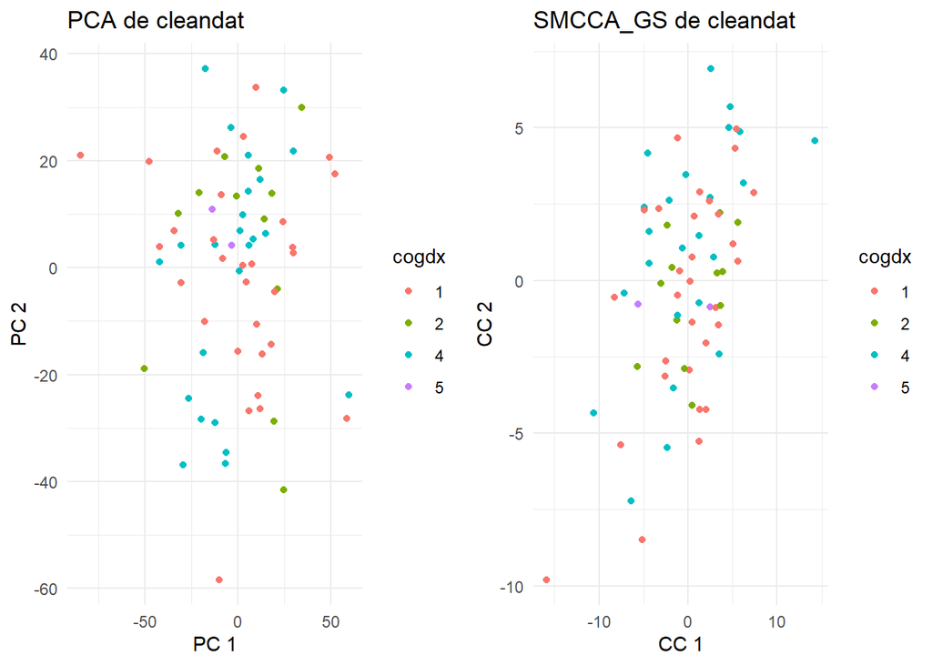

```r
grid.arrange(p1_cleandat, c1_cleandat, ncol = 2)
```

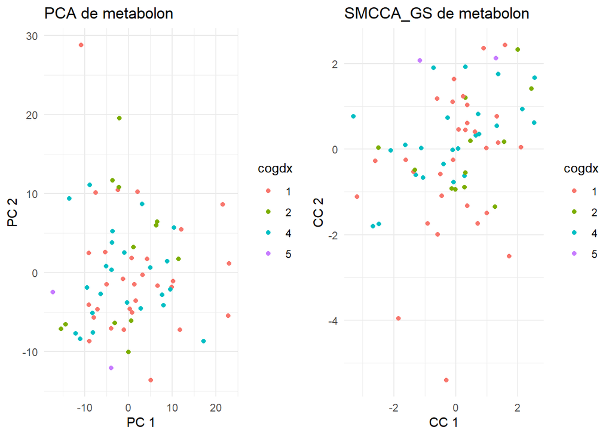

```r
grid.arrange(p1_metabolon, c1_metabolon, ncol = 2)
```

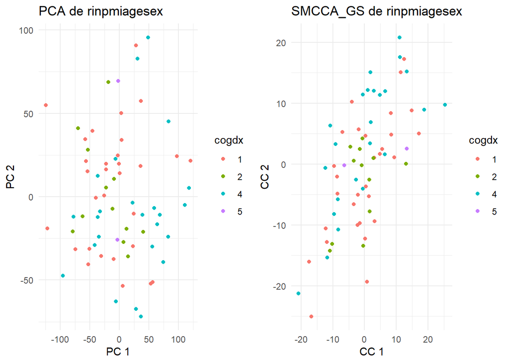

```r
grid.arrange(p1_rinpmiagesex, c1_rinpmiagesex, ncol = 2)
```

En estas gráficas podemos ver una comparativa entre las dos primeras componentes principales (o variables canónicas) obtenidas por cada técnica en cada conjunto de datos. En ellas, se puede apreciar que PCA y SMCCA-GS parecen compartir una cierta semejanza en la disposición de los puntos y que, en ninguno de los dos casos podemos ver, de forma visual, que alguna de las dos técnicas logre agrupar los puntos según el diagnóstico clínico final de los pacientes (variable `cogdx`).

## 6.2 Correlaciones entre pares de componentes generados por cada método

En las siguientes imágenes se visualizan las matrices de correlación entre cada par de conjuntos de datos comparando ambas técnicas:

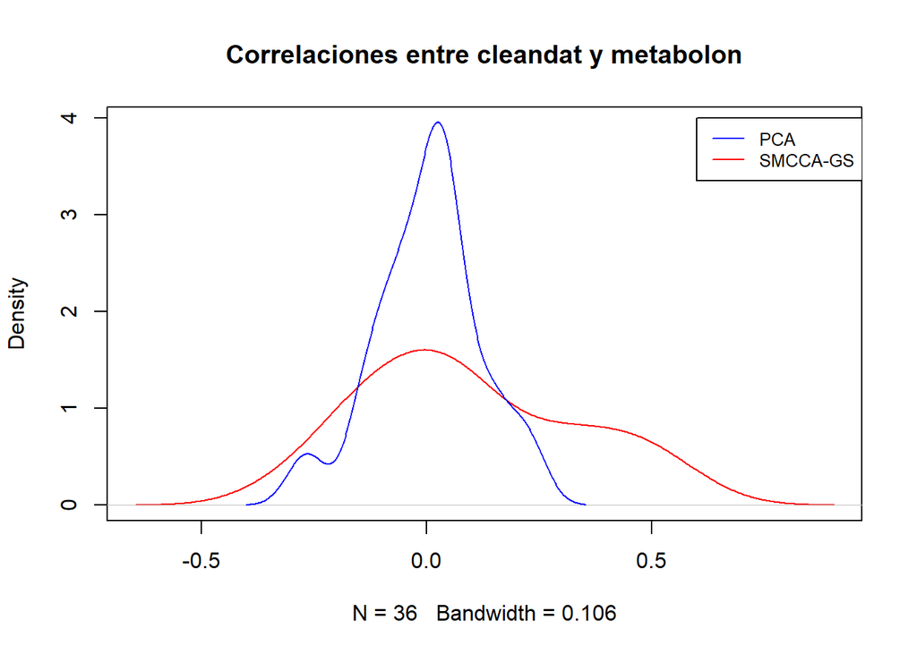

```r
# Comparamos las matrices de correlación entre los dos métodos
plot(density(cor_SMCCA_GS_cleandat_metabolon),
     ylim = range(density(cor_SMCCA_GS_cleandat_metabolon)$y, density(cor_cleandat_metabolon)$y),
     xlim = range(density(cor_SMCCA_GS_cleandat_metabolon)$x, density(cor_cleandat_metabolon)$x),
     main = "Correlaciones entre cleandat y metabolon",
     col = "red")
lines(density(cor_cleandat_metabolon), col = "blue")
legend(x=0.6, y = 4, legend = c("PCA", "SMCCA-GS"), col = c("blue", "red"), lty=1, cex=0.8)
```

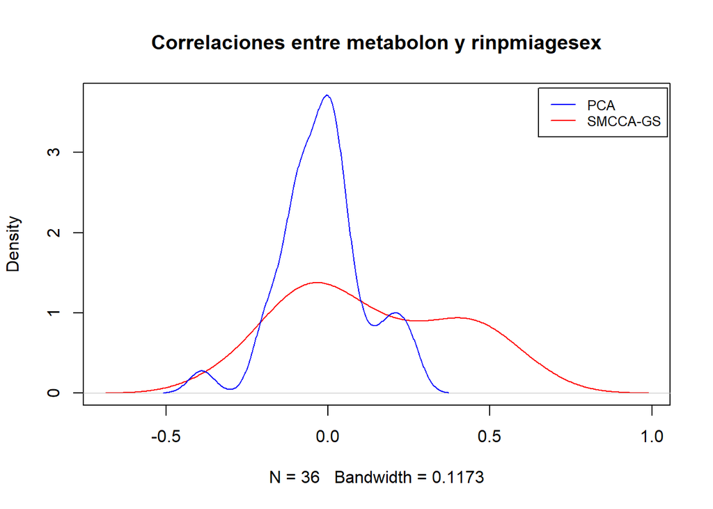

```r
plot(density(cor_SMCCA_GS_metabolon_rinpmiagesex),
     ylim = range(density(cor_SMCCA_GS_metabolon_rinpmiagesex)$y, density(cor_metabolon_rinpmiagesex)$y),
     xlim = range(density(cor_SMCCA_GS_metabolon_rinpmiagesex)$x, density(cor_metabolon_rinpmiagesex)$x),
     main = "Correlaciones entre metabolon y rinpmiagesex",
     col = "red")
lines(density(cor_metabolon_rinpmiagesex), col = "blue")
legend(x=0.65, y = 3.8, legend = c("PCA", "SMCCA-GS"), col = c("blue", "red"), lty=1, cex=0.8)
```

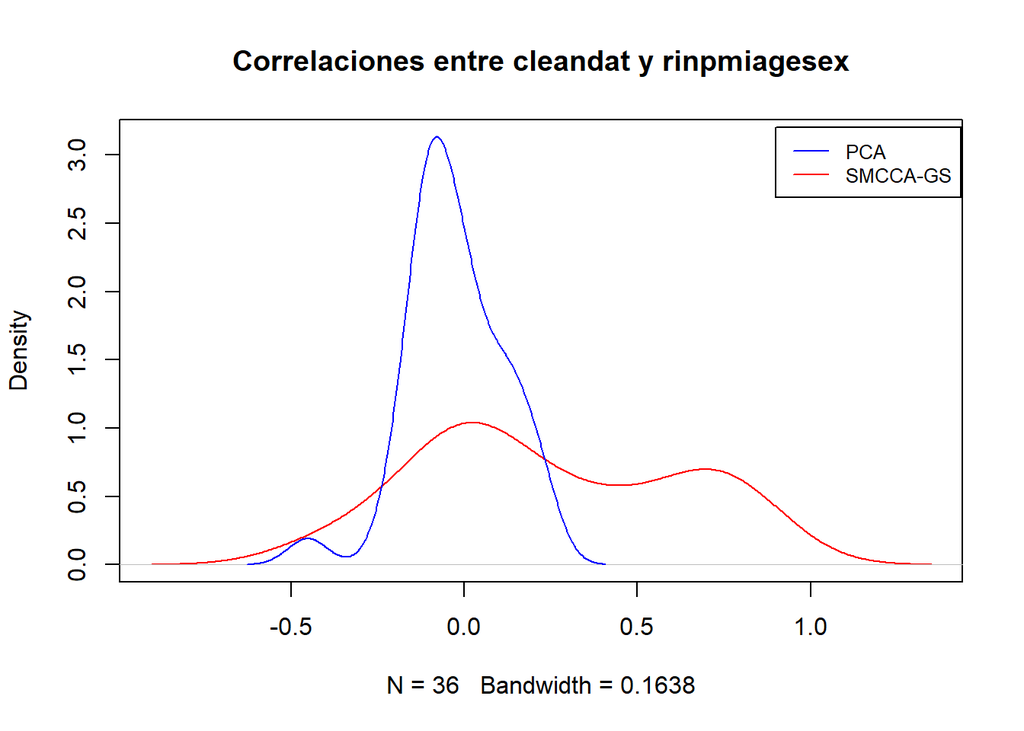

```r
plot(density(cor_SMCCA_GS_cleandat_rinpmiagesex),
     ylim = range(density(cor_SMCCA_GS_cleandat_rinpmiagesex)$y, density(cor_cleandat_rinpmiagesex)$y),
     xlim = range(density(cor_SMCCA_GS_cleandat_rinpmiagesex)$x, density(cor_cleandat_rinpmiagesex)$x),
     main = "Correlaciones entre cleandat y rinpmiagesex",
     col = "red")
lines(density(cor_cleandat_rinpmiagesex), col = "blue")
legend(x=0.9, y = 3.2, legend = c("PCA", "SMCCA-GS"), col = c("blue", "red"), lty=1, cex=0.8)
```

En conjunto, estas imágenes muestran que la técnica PCA tiene una ventaja sobre SMCCA-GS en la obtención de componentes principales ortogonales entre sí.

## 6.3 Resultados de los bosques aleatorios

Para finalizar, vamos a volver a visualizar los resultados obtenidos tras la aplicación de la técnica de aprendizaje computacional “bosques aleatorios” y a hacer unos breves comentarios sobre ellos. Primero se muestran los resultados de PCA y después los de SMCCA-GS:

```r
confusionMatrix(data = pred.test_PCA_ROSMAP, reference = pca_result_total_ROSMAP.Test[[pca_result_total_ROSMAP.Var.Salida.Usada]])
```

```
## Confusion Matrix and Statistics
##
##           Reference
## Prediction 1 2 4 5
##          1 4 2 3 0
##          2 0 0 0 0
##          4 2 0 1 0
##          5 0 0 0 0
##
## Overall Statistics
##
##                Accuracy : 0.4167
##                  95% CI : (0.1517, 0.7233)
##     No Information Rate : 0.5
##     P-Value [Acc > NIR] : 0.8062
##
##                   Kappa : -0.0769
##
##  Mcnemar's Test P-Value : NA
##
## Statistics by Class:
##
##                      Class: 1 Class: 2 Class: 4 Class: 5
## Sensitivity            0.6667   0.0000  0.25000       NA
## Specificity            0.1667   1.0000  0.75000        1
## Pos Pred Value         0.4444      NaN  0.33333       NA
## Neg Pred Value         0.3333   0.8333  0.66667       NA
## Prevalence             0.5000   0.1667  0.33333        0
## Detection Rate         0.3333   0.0000  0.08333        0
## Detection Prevalence   0.7500   0.0000  0.25000        0
## Balanced Accuracy      0.4167   0.5000  0.50000       NA
```

```r
confusionMatrix(data = pred.test_SMCCA_GS_ROSMAP, reference = SMCCA_GS_total_ROSMAP.Test[[SMCCA_GS_total_ROSMAP.Var.Salida.Usada]])
```

```
## Confusion Matrix and Statistics
##
##           Reference
## Prediction 1 2 4 5
##          1 5 1 1 0
##          2 0 0 0 0
##          4 1 1 3 0
##          5 0 0 0 0
##
## Overall Statistics
##
##                Accuracy : 0.6667
##                  95% CI : (0.3489, 0.9008)
##     No Information Rate : 0.5
##     P-Value [Acc > NIR] : 0.1938
##
##                   Kappa : 0.4146
##
##  Mcnemar's Test P-Value : NA
##
## Statistics by Class:
##
##                      Class: 1 Class: 2 Class: 4 Class: 5
## Sensitivity            0.8333   0.0000   0.7500       NA
## Specificity            0.6667   1.0000   0.7500        1
## Pos Pred Value         0.7143      NaN   0.6000       NA
## Neg Pred Value         0.8000   0.8333   0.8571       NA
## Prevalence             0.5000   0.1667   0.3333        0
## Detection Rate         0.4167   0.0000   0.2500        0
## Detection Prevalence   0.5833   0.0000   0.4167        0
## Balanced Accuracy      0.7500   0.5000   0.7500       NA
```

En la siguiente tabla se muestran la precisión y los intervalos obtenidos para cada técnica:

|  | PCA | SMCCA-GS |
| --- | --- | --- |
| Precisión | 0.4167 | 0.6667 |
| Intervalo de confianza | (0.1517, 0.7233) | (0.3489, 0.9008) |

Por otra parte, el p-valor obtenido en ambos casos es mayor que 0.05. Esto implica que no hay una diferencia significativa entre clasificar los puntos según el modelo predicito y clasificarlos de manera aleatoria.

# 7 Conclusión

Hemos realizado una comparación entre las técnicas PCA y SMCCA-GS con datos del proyecto ROSMAP. Para realizar esta comparación, hemos aplicado PCA sobre cada uno de los tres conjuntos de datos, por separado, y SMCCA-GS sobre los mismos tres conjuntos. En la comparativa de las distancias que hemos realizado hemos podido comprobar que SMCCA-GS realiza una mejor separación que PCA. Resultados análogos se han podido ver en la comparativa de las correlaciones y en la aplicación de la técnica de aprendizaje computacional “bosques aleatorios”, aunque en este último caso, hemos de notar que ninguna de las dos técnicas ha obtenido buenos resultados. Esto último seguramente se deba al escaso número de ejemplos con los que hemos podido trabajar.